# When does removing an invasive plant repay its carbon cost?

Break-even times across seven invaded systems, and why neither removal nor retention can be credited

Author

[Murphy, S](https://scholar.google.com/citations?hl=en&user=jDGq9I4AAAAJ)

Published

July 30, 2026

Keywords

Invasive species, Carbon budget, Ecological restoration, Voluntary carbon market, Biodiversity credits, Invasion ecology

**Running title:** Carbon break-even after invasive plant removal (43 characters)

**Target venue:** *Global Change Biology*, Research Article. Word limit 8,000 over Introduction, Methods, Results, Discussion and Acknowledgements only; abstract, references and figure legends excluded. Abstract 300 words, unstructured. No cap on figures, tables or references. Free format submission, so no reference style is prescribed until acceptance. Line numbering is required and must be enabled in Word at submission; Quarto does not emit it to docx.

```r
# Rendering this manuscript runs the entire analysis. Every number in the text, every
# table and every figure below is produced by the R code in this document, so the prose
# and the results cannot drift apart. Nothing is fetched over the network: both inputs
# are parameter tables held in 02.inputs, each row carrying the source it was read from.
# Base R only, no packages beyond knitr, so the document renders on any R installation.

library(knitr)
knitr::opts_chunk$set(echo = TRUE, warning = FALSE, message = FALSE)

repo <- normalizePath("..")
IN   <- file.path(repo, "02.inputs")
TBL  <- file.path(repo, "03.outputs", "tables")
FIG  <- file.path(repo, "03.outputs", "figures")
dir.create(TBL, recursive = TRUE, showWarnings = FALSE)
dir.create(FIG, recursive = TRUE, showWarnings = FALSE)

set.seed(20260730)          # the Monte Carlo below is reproducible from this seed
NSIM      <- 10000          # draws per system
HORIZON   <- 300            # years; break-even is reported as not reached beyond this
CREDIT    <- 40             # years; the AFOLU crediting period used for the crediting test
DEMINIMIS <- 0.05           # the 5 percent de minimis threshold used by Verra
DEFAULT_CV <- 0.20          # dispersion assumed where a source reports none
CO2_C     <- 44 / 12        # conversion from carbon to carbon dioxide equivalent

# formatting helpers used throughout
f1  <- function(x) sprintf("%.1f", x)
f2  <- function(x) sprintf("%.2f", x)
f0  <- function(x) formatC(round(x), format = "d", big.mark = ",")
pc  <- function(x) sprintf("%.0f%%", 100 * x)
yr  <- function(x) ifelse(is.na(x), "not reached", sprintf("%.0f", x))
```

```r
# The parameter table is long format, one row per parameter per system, so provenance
# travels with the value. Tier A is measured with dispersion, B measured as a point
# estimate, C derived by arithmetic shown in this document, D transferred from another
# system or a global default because nothing system specific exists.
par_long <- read.csv(file.path(IN, "carbon-parameters.csv"), stringsAsFactors = FALSE)
sysmeta  <- read.csv(file.path(IN, "systems.csv"), stringsAsFactors = FALSE)

# any parameter still flagged provisional is a hard stop: the manuscript must not report
# a number that has not been read from a source
prov <- par_long[par_long$tier == "P", ]
if (nrow(prov) > 0) {
  stop("Provisional parameters remain in carbon-parameters.csv: ",
       paste(unique(paste(prov$system_id, prov$parameter)), collapse = ", "))
}

# pull a single parameter for a single system
getp <- function(sid, p, field = "value") {
  r <- par_long[par_long$system_id == sid & par_long$parameter == p, ]
  if (nrow(r) == 0) return(NA_real_)
  as.numeric(r[[field]][1])
}
gett <- function(sid, p) {
  r <- par_long[par_long$system_id == sid & par_long$parameter == p, ]
  if (nrow(r) == 0) return(NA_character_)
  r$tier[1]
}

SYS <- sysmeta$system_id
names(SYS) <- sysmeta$system_short

# Evidence class is derived from the parameter tiers rather than asserted in the input file,
# so the manuscript cannot describe a system as quantified unless the parameters say so. A
# system is quantified only where both stocks and the invader's own aboveground carbon are
# measured or derived rather than transferred from elsewhere.
KEYPAR <- c("C_inv", "C_nat", "AGB_inv")
sysmeta$evidence_class <- sapply(sysmeta$system_id, function(s)
  if (all(sapply(KEYPAR, function(p) gett(s, p)) %in% c("A", "B", "C")))
    "Quantified" else "Indicative")
n_quant <- sum(sysmeta$evidence_class == "Quantified")
n_indic <- sum(sysmeta$evidence_class == "Indicative")
```

```r
# ---------------------------------------------------------------------------
# The two trajectory break-even model
# ---------------------------------------------------------------------------
# Both scenarios are monomolecular approaches to an asymptote, the standard form for
# stock recovery toward a carrying capacity. C(t) = K - (K - C0) exp(-r t).
#
# LEAVE: the invader is retained. The stock relaxes from the measured invaded stock
# C_inv toward the invaded asymptote K_inv at rate r_inv. Where the invaded state is
# already at equilibrium, K_inv equals C_inv and the trajectory is flat.
#
# REMOVE: at t = 0 the stock falls instantaneously by the initial carbon loss D, then relaxes
# from that reduced starting point toward the native reference stock C_nat at rate
# r_nat, the rate at which native vegetation reaccumulates carbon on cleared ground.

approach <- function(t, C0, K, r) K - (K - C0) * exp(-r * t)

C_leave  <- function(t, C_inv, K_inv, r_inv) approach(t, C_inv, K_inv, r_inv)

# The initial loss is the carbon the removal puts into the atmosphere, or removes from the site
# without replacing: the released fraction of the invader's own aboveground stock, plus
# any soil carbon lost to the disturbance, plus the operational emissions of clearing.
initial_loss <- function(AGB_inv, f_rel, dSOC, E_op) AGB_inv * f_rel + dSOC + E_op

C_remove <- function(t, C_inv, D, C_nat, r_nat) approach(t, C_inv - D, C_nat, r_nat)

# Carbon break-even is the first time the removal trajectory catches the leave trajectory.
# This is break-even in the sense of Mitchell et al., a comparison against the counterfactual,
# not stock recovery in the sense of returning to the pre-removal stock. Both are reported.
crossing <- function(f, horizon = HORIZON) {
  if (f(0) >= 0) return(0)
  if (f(horizon) < 0) return(NA_real_)
  uniroot(f, c(0, horizon), tol = 1e-6)$root
}

breakeven_time <- function(p) {
  crossing(function(t) C_remove(t, p$C_inv, p$D, p$C_nat, p$r_nat) -
                       C_leave(t, p$C_inv, p$K_inv, p$r_inv))
}

recovery_time <- function(p) {
  crossing(function(t) C_remove(t, p$C_inv, p$D, p$C_nat, p$r_nat) - p$C_inv)
}

# Net carbon benefit of removal relative to leaving the invader in place, at time t.
# This is the quantity a project would claim, and it is negative for as long as the
# removal trajectory sits below the counterfactual.
net_benefit <- function(t, p) {
  C_remove(t, p$C_inv, p$D, p$C_nat, p$r_nat) - C_leave(t, p$C_inv, p$K_inv, p$r_inv)
}

# Rate constant implied by a chronosequence: a state observed at C_t after t years of
# recovery from C_0 toward an asymptote K. Used where a source reports a recovery
# observation rather than a rate.
rate_from_chrono <- function(C0, Ct, K, t) {
  if (any(!is.finite(c(C0, Ct, K, t))) || K <= Ct || K <= C0) return(NA_real_)
  -log((K - Ct) / (K - C0)) / t
}
```

```r
# Assemble the point estimate parameter set for each system from the long table.
PARNAMES <- c("C_inv", "C_nat", "AGB_inv", "K_inv", "r_inv", "r_nat",
              "f_rel", "dSOC", "E_op")

pars_point <- lapply(SYS, function(sid) {
  p <- as.list(setNames(sapply(PARNAMES, function(x) getp(sid, x)), PARNAMES))
  # where a source gives no invaded asymptote the invaded state is treated as at
  # equilibrium, which is the conservative assumption for the removal case
  if (!is.finite(p$K_inv)) { p$K_inv <- p$C_inv; p$r_inv <- 0 }
  if (!is.finite(p$r_inv)) p$r_inv <- 0
  p$D <- initial_loss(p$AGB_inv, p$f_rel, p$dSOC, p$E_op)
  p
})
names(pars_point) <- SYS

# Point estimate results
res_point <- do.call(rbind, lapply(SYS, function(sid) {
  p <- pars_point[[sid]]
  data.frame(
    system_id = sid,
    initial_loss      = p$D,
    breakeven    = breakeven_time(p),
    recovery   = recovery_time(p),
    nb40      = net_benefit(CREDIT, p),
    nb100     = net_benefit(100, p),
    stringsAsFactors = FALSE)
}))
rownames(res_point) <- NULL
```

```r
# ---------------------------------------------------------------------------
# Uncertainty
# ---------------------------------------------------------------------------
# Every parameter is drawn from a normal distribution centred on its point estimate
# with the dispersion its source reports. Where a source reports a standard error and a
# sample size the standard deviation is recovered as SE * sqrt(n); where it reports no
# dispersion at all the parameter is given a coefficient of variation of 0.20, and the
# consequence of that choice is examined in the sensitivity analysis. Stocks and rates
# are truncated at zero, and f_rel is truncated to the unit interval, because negative
# stocks and negative release fractions are not physically meaningful.

draw_sd <- function(sid, p) {
  s <- getp(sid, p, "sd")
  n <- getp(sid, p, "n")
  v <- getp(sid, p, "value")
  if (is.finite(s)) {
    # sources reporting a standard error alongside n are converted to a standard deviation
    if (identical(par_long$disp[par_long$system_id == sid & par_long$parameter == p][1], "se") &&
        is.finite(n)) return(s * sqrt(n))
    return(s)
  }
  abs(v) * DEFAULT_CV
}

rtrunc <- function(n, mean, sd, lo = 0, hi = Inf) {
  x <- rnorm(n, mean, sd)
  x[x < lo] <- lo
  x[x > hi] <- hi
  x
}

simulate_system <- function(sid, nsim = NSIM) {
  p0 <- pars_point[[sid]]
  d  <- list()
  for (nm in c("C_inv", "C_nat", "AGB_inv", "dSOC", "E_op")) {
    d[[nm]] <- rtrunc(nsim, p0[[nm]], draw_sd(sid, nm))
  }
  d$r_nat <- rtrunc(nsim, p0$r_nat, draw_sd(sid, "r_nat"), lo = 1e-6)
  d$f_rel <- rtrunc(nsim, p0$f_rel, draw_sd(sid, "f_rel"), lo = 0, hi = 1)
  d$K_inv <- if (identical(p0$K_inv, p0$C_inv)) d$C_inv else
             rtrunc(nsim, p0$K_inv, draw_sd(sid, "K_inv"))
  d$r_inv <- rep(p0$r_inv, nsim)

  out <- data.frame(breakeven = numeric(nsim), recovery = numeric(nsim), nb40 = numeric(nsim))
  for (i in seq_len(nsim)) {
    p <- list(C_inv = d$C_inv[i], C_nat = d$C_nat[i], K_inv = d$K_inv[i],
              r_inv = d$r_inv[i], r_nat = d$r_nat[i])
    p$D <- initial_loss(d$AGB_inv[i], d$f_rel[i], d$dSOC[i], d$E_op[i])
    out$breakeven[i]  <- breakeven_time(p)
    out$recovery[i] <- recovery_time(p)
    out$nb40[i]    <- net_benefit(CREDIT, p)
  }
  out
}

sims <- lapply(SYS, simulate_system)
names(sims) <- SYS

# summarise: median and 95 percent interval of break-even time among draws that reach break-even,
# and the probability that break-even is never reached inside the 300 year horizon
res_mc <- do.call(rbind, lapply(SYS, function(sid) {
  s  <- sims[[sid]]
  ok <- is.finite(s$breakeven)
  q  <- if (any(ok)) quantile(s$breakeven[ok], c(0.025, 0.5, 0.975)) else rep(NA_real_, 3)
  okb <- is.finite(s$recovery)
  data.frame(system_id = sid,
             p_never   = mean(!ok),
             breakeven_lo = q[1], breakeven_md = q[2], breakeven_hi = q[3],
             # stock recovery is summarised the same way as break-even so the two columns of Table 3 are
             # the same kind of quantity. Where the invaded state is static the two coincide
             # by construction, which is a useful check on the code.
             recovery_md = if (any(okb)) median(s$recovery[okb]) else NA_real_,
             p_never_b  = mean(!okb),
             nb40_md   = median(s$nb40),
             nb40_lo   = quantile(s$nb40, 0.025),
             nb40_hi   = quantile(s$nb40, 0.975),
             p_nb40_neg = mean(s$nb40 < 0),
             stringsAsFactors = FALSE)
}))
rownames(res_mc) <- NULL

res <- merge(merge(sysmeta, res_point, by = "system_id"), res_mc, by = "system_id")
res <- res[order(res$display_order), ]
```

```r
# ---------------------------------------------------------------------------
# The crediting test
# ---------------------------------------------------------------------------
# Two questions decide whether a removal project could be credited at all under the
# accounting rules the standards actually use.
#
# 1. Does the project generate a positive net benefit inside the crediting period? If
#    the removal trajectory is still below the counterfactual at year 40, there is
#    nothing to credit no matter how the rules are written.
# 2. Is the initial carbon loss small enough to be waved through as de minimis? Verra permits
#    an omitted decrease in carbon stocks only where it is below 5 percent of the total
#    greenhouse gas benefit the project generates. A removal whose initial loss exceeds that
#    share of its own benefit must account for the initial loss explicitly, and no approved
#    methodology outside the matched baseline design provides a way to do so.

res$claimable   <- res$nb40_md > 0
res$loss_share  <- ifelse(res$nb40_md > 0, res$initial_loss / res$nb40_md, NA_real_)
res$deminimis   <- is.finite(res$loss_share) & res$loss_share < DEMINIMIS
res$verdict <- ifelse(!res$claimable, "no claimable benefit at 40 yr",
               ifelse(res$deminimis,  "claimable, initial loss de minimis",
                                      "claimable, initial loss must be accounted"))

# headline values, defined here because the abstract quotes them and inline R is evaluated
# in document order
maxloss   <- res$system_short[which.max(res$initial_loss)]
maxloss_v <- max(res$initial_loss)
minloss_v <- min(res$initial_loss)
```

```r
aud <- read.csv(file.path(IN, "standards-audit.csv"), stringsAsFactors = FALSE)
CRIT <- c(introduce_prohibited   = "Introduction prohibited",
          removal_named_eligible = "Removal a named eligible activity",
          removal_creditable_carbon = "Carbon effect of removal creditable",
          biomass_loss_resolved  = "Invader biomass initial loss resolved",
          species_named          = "Any invasive taxon named",
          creditable_non_carbon  = "Removal creditable under a non carbon instrument")

audm <- reshape(aud[, c("standard_short", "criterion", "code")],
                idvar = "standard_short", timevar = "criterion", direction = "wide")
names(audm) <- sub("^code\\.", "", names(audm))
audm <- audm[, c("standard_short", names(CRIT))]
STORD <- c("Verra", "Plan Vivo", "Gold Standard", "ACR", "CAR", "Article 6.4", "ACCU")
audm <- audm[match(STORD, audm$standard_short), ]
rownames(audm) <- NULL
```

# Abstract

Removing an invasive plant is one of the few restoration actions with an unambiguous biodiversity rationale and no reliable way to pay for it. Carbon finance fails it for a reason that is arithmetic rather than administrative: a woody invader is itself a carbon stock, so clearing it registers as an emission against a carbon-rich baseline and meets, on its face, every test for baseline gaming. Whether removal is nevertheless a carbon gain depends on the time for recovering native vegetation to overtake the trajectory the invader would have followed if left in place. We adapt the carbon accounting framework developed for biofuel and bioenergy to invasive plant removal and apply it to 7 invaded systems spanning six invader functional types, from annual grasses to woody nitrogen fixers. Initial carbon losses span 0.4 to 51.0 Mg C per hectare and break-even times run from immediate to never, ordered by the functional type of the invader. Only 3 systems can be parameterised entirely from measurement, because the recovery rate that dominates the calculation is barely measured anywhere. On the single site where intact, degraded and restored classes were all measured, the sign of the invasion effect changes with the comparison chosen, across a range wider than the invaded stand’s entire aboveground stock. We then audit six voluntary carbon standards and one compliance scheme against their own current requirement documents. The failure is symmetrical: removal cannot be credited because clearing is an emission against the baseline, and retention cannot be credited because retention is the baseline and nothing is additional to itself. Whichever action the arithmetic favours, the accounting returns nothing, and it does so regardless of the ecology. The activity is monetised today only as biochar feedstock and as a biodiversity credit, neither of which rewards the land carbon effect.

# 1. Introduction

Invasive species are among the recognised direct drivers of biodiversity loss, and the first global assessment devoted to them concluded that they are also among the most expensive, with costs that have risen steeply over recent decades (Diagne et al., 2021; IPBES, 2023). The international response has set targets for their control, but the financing to meet those targets has no obvious source. The Kunming-Montreal framework asks parties to reduce the introduction and establishment of invasive species and, separately, to restore a substantial share of degraded ecosystems, while relying on private finance to help pay for both (Convention on Biological Diversity, 2022).

Restoration finance has consolidated around carbon, and invasive removal fits that instrument badly. Almost every other restoration action adds something: trees, wetland, soil carbon, structural complexity. Removal takes something away, and in the case of a woody invader what it takes away is biomass carbon that a carbon accountant is obliged to count. A proponent who clears a dense stand of an invasive tree has, on the face of the ledger, done what the market is designed to prevent. The clearing is deliberate, it is carried out by the proponent, and it is motivated by carbon finance. Those three facts are the standard test for baseline gaming, and a genuine restoration project satisfies all of them.

The scientific question underneath the accounting question has been answered only in fragments. A substantial literature quantifies what invasion does to ecosystem carbon, beginning with the finding that invasion alters carbon and nitrogen pools systematically and often upward (Liao et al., 2008; Peltzer, Allen, Lovett, Whitehead, & Wardle, 2010; Vilà et al., 2011), and continuing into mechanism through soil biota, microbial biomass and heterotrophic respiration (He et al., 2025; Negesse et al., 2025; Raheem et al., 2024). A much thinner literature follows what happens after removal, and it is dominated by endpoints other than carbon. The most recent global synthesis of post-removal revegetation reports native cover recovering by nearly half and non-native cover falling by more than a quarter, with carbon appearing only as an ordering claim, that abundance recovers faster than carbon stocks, which recover faster than diversity (Ahmad et al., 2026). The two halves have never been joined into the quantity a financing decision requires, which is the time the removal trajectory takes to overtake the counterfactual.

That quantity has a well developed analogue. Biofuel accounting confronted the same structure when it became clear that clearing native vegetation for an energy crop incurs an immediate initial carbon loss that the crop’s annual savings must repay, with repayment periods running to centuries in the worst cases (Fargione, Hill, Tilman, Polasky, & Hawthorne, 2008; Searchinger et al., 2008). Forest bioenergy accounting then sharpened the idea by separating stock recovery, the return to the pre-intervention stock, from break-even, the point at which the intervention overtakes the trajectory the stand would otherwise have followed (Mitchell, Harmon, & O’Connell, 2012). Break-even, not stock recovery, is the quantity relevant to a counterfactual-based crediting system, and it is the quantity computed here. The same literature is candid about the framework’s fragility, since methodological choices alone can move break-even estimates by two orders of magnitude (Jonker, Junginger, & Faaij, 2014), which is why the accounting boundary and the counterfactual are fixed here before any result is computed.

The nearest existing treatment of invasive control as climate action concerns invasive mammals on islands (Honzák et al., 2024), where the eradication target holds no standing biomass and the accounting problem examined here never arises. That asymmetry between animal and woody-plant invaders is the gap this paper occupies.

Three questions follow. First, across invaded systems that differ in the functional type of the invader, how long is the time to carbon break-even after removal, and in which systems is it never reached? Second, given those answers, could a removal project be credited under the accounting rules that carbon standards actually apply? Third, where the carbon answer is unfavourable, what instrument is appropriate instead?

# 2. Methods

## 2.1 Systems and the evidence base

```r
t1 <- sysmeta[order(sysmeta$display_order),
              c("system_short", "invader", "region", "functional_type", "evidence_class")]
names(t1) <- c("System", "Invader", "Region", "Functional type", "Evidence")
kable(t1, row.names = FALSE)
write.csv(t1, file.path(TBL, "table-1-systems.csv"), row.names = FALSE)
```

| System | Invader | Region | Functional type | Evidence |
| --- | --- | --- | --- | --- |
| Prosopis rangeland | Prosopis juliflora | Baringo, Kenya | Woody nitrogen-fixing tree | Quantified |
| Cheatgrass steppe | Bromus tectorum | Great Basin, USA | Annual grass | Quantified |
| Tidal marsh | Phragmites australis | Northeast USA tidal marsh | Wetland graminoid | Indicative |
| Dry deciduous forest | Lantana camara | Madhya Pradesh, India | Thicket-forming shrub | Quantified |
| Atlantic Forest regrowth | Acacia mangium and A. mearnsii | Atlantic Forest, Brazil | Woody nitrogen-fixing tree | Indicative |
| Everglades wetland | Melaleuca quinquenervia | Florida Everglades, USA | Woody wetland tree | Indicative |
| Tropical freshwater | Pontederia crassipes | Tropical and subtropical lakes | Floating aquatic | Indicative |

Systems were selected to span the functional types across which the carbon consequence of removal is expected to differ, rather than to be a representative sample of invaded ecosystems, which the available data would not support. The selection is deliberately adversarial to the framing advanced here: it includes the systems in which removal is most likely to be a carbon loss as well as those in which it is most likely to be a gain.

The evidence classification in Table 1 is derived from the parameter tiers rather than asserted, so a system counts as quantified only where both ecosystem stocks and the invader’s own aboveground carbon come from measurement or from arithmetic on measurements. On that test 3 of the 7 systems are quantified and 4 are indicative. That ratio is itself a result. It is not possible at present to assemble a fully measured break-even calculation for most of the world’s best known plant invasions, and the reader should treat the indicative systems as showing the sign and rough magnitude of an effect rather than its value.

## 2.2 The break-even model

The model compares two futures from the moment of intervention. Under the leave scenario the invader is retained and total ecosystem carbon relaxes toward the asymptote of the invaded state. Under the remove scenario the stock falls instantaneously by the initial carbon loss, then relaxes toward the native reference stock at the rate at which native vegetation reaccumulates carbon on cleared ground. Both trajectories take the monomolecular form, which is the standard representation of stock recovery toward a carrying capacity and requires only a starting stock, an asymptote and a rate constant.

The initial carbon loss has three components: the fraction of the invader’s own aboveground carbon released to the atmosphere within a year of clearing, any soil organic carbon lost to the disturbance itself, and the operational emissions of the clearing work. Carbon that leaves the site in durable form, as timber or biochar, is not part of the initial loss, which is why the biochar route discussed below changes the arithmetic rather than merely the finance.

Carbon break-even is the first time at which the removal trajectory crosses the leave trajectory. Stock recovery, reported alongside it, is the first time at which the removal trajectory returns to the pre-removal stock. The two differ whenever the invaded state is not at equilibrium, and the difference matters because a crediting system pays for the former while intuition tends to reach for the latter.

## 2.3 The counterfactual, and why it is a choice rather than a fact

The break-even calculation compares removal against a stated alternative, and the alternative is not given by the data. Three are defensible for any invaded site. The site could be compared against the intact native community, which is what almost every paired study in this literature measures. It could be compared against the degraded but uninvaded state, which is what the site would plausibly have become had the invader not arrived, given that the disturbance which admitted the invader would still have occurred. Or it could be compared against what active restoration could achieve, which is the alternative facing a manager holding a budget.

These are different questions and they do not share an answer. Where all three classes have been measured on one site, the sign of the estimated carbon effect of invasion depends on which is chosen.

```r
cls <- read.csv(file.path(IN, "counterfactual-classes.csv"), stringsAsFactors = FALSE)
cls$total <- cls$soc + cls$agc

# the invaded state used in the break-even model is the dense stand
inv_tot <- cls$total[cls$class == "Prosopis high density"]

cf <- cls[cls$class_type != "invaded", c("class", "class_type", "soc", "agc", "total")]
cf$effect  <- inv_tot - cf$total
cf$verdict <- ifelse(cf$effect > 0, "gain", "loss")
cf <- cf[order(-cf$total), ]
cf_span <- diff(range(cf$effect))
```

```r
t2b <- data.frame(
  `Counterfactual` = cf$class,
  `Soil C` = f1(cf$soc), `Aboveground C` = f1(cf$agc), `Total` = f1(cf$total),
  `Effect of invasion` = sprintf("%+.2f", cf$effect),
  `Verdict` = cf$verdict,
  check.names = FALSE, stringsAsFactors = FALSE)
kable(t2b, row.names = FALSE)
write.csv(t2b, file.path(TBL, "table-2b-counterfactual.csv"), row.names = FALSE)
```

Table 2: The counterfactual sets the sign. Total ecosystem carbon of every land-cover class measured on one site in one year by one team with one protocol, and the estimated effect of invasion computed against each candidate counterfactual in turn. The invaded state throughout is the dense Prosopis stand at 52.5 Mg C per hectare. Soil carbon is to 1 m depth and aboveground carbon is from the same plots.

| Counterfactual | Soil C | Aboveground C | Total | Effect of invasion | Verdict |
| --- | --- | --- | --- | --- | --- |
| Pristine grassland | 49.8 | 6.0 | 55.8 | -3.27 | loss |
| Restored grassland | 44.7 | 3.2 | 47.9 | +4.64 | gain |
| Degraded grassland | 31.5 | 0.7 | 32.2 | +20.30 | gain |

Invasion is a carbon loss of 3.27 Mg C per hectare against the intact grassland, a gain of 4.64 against the restored grassland, and a gain of 20.30 against the degraded grassland. The spread between the extreme comparisons is 23.6 Mg C per hectare, which exceeds the entire aboveground carbon stock of the invaded stand. Nothing about the ecosystem differs between these three statements. Only the question does.

This matters for the present analysis because the break-even model must adopt one of them, and it adopts the second. The retention trajectory represents the invaded state persisting, which is the alternative actually facing a proponent deciding whether to clear. Comparing instead against the intact native community would attribute to the invader whatever degradation preceded and permitted it, and comparing against the restored state would presuppose the very restoration whose value is in question. The choice is conservative for the removal case in the sense that it neither credits nor penalises the invader for the site’s prior condition, but it is a choice, and results computed under one counterfactual should not be read as though they held under another.

The wider literature rarely states which comparison it is making. Conservation science confronted the same problem two decades ago and largely resolved it by importing counterfactual reasoning from programme evaluation (Ferraro & Pattanayak, 2006); invasion ecology has not yet done so at scale, and the paired invaded-versus-uninvaded design that dominates the field cannot separate the effect of the invader from the effect of the disturbance that admitted it.

## 2.4 Parameterisation and uncertainty

```r
t2 <- par_long[, c("system_id", "parameter", "value", "sd", "n", "units", "source_key", "tier")]
t2 <- t2[order(match(t2$system_id, sysmeta$system_id[order(sysmeta$display_order)]),
               match(t2$parameter, PARNAMES)), ]
names(t2) <- c("System", "Parameter", "Value", "SD", "n", "Units", "Source", "Tier")
kable(t2, row.names = FALSE, digits = 3)
write.csv(t2, file.path(TBL, "table-2-parameters.csv"), row.names = FALSE)
```

Table 3: Parameter values, dispersion and provenance. Tier A is measured in the cited source for that system with a dispersion estimate, B measured as a point estimate, C derived by arithmetic shown in this document, D transferred from another system or a global default. Every tier D parameter is a stated limitation.

| System | Parameter | Value | SD | n | Units | Source | Tier |
| --- | --- | --- | --- | --- | --- | --- | --- |
| prosopis | C_inv | 52.510 | 7.540 | 10 | Mg C ha-1 | mbaabu2020restoration | C |
| prosopis | C_nat | 55.780 | 7.880 | 10 | Mg C ha-1 | mbaabu2020restoration | C |
| prosopis | AGB_inv | 12.460 | 6.360 | 5 | Mg C ha-1 | mbaabu2020restoration | A |
| prosopis | r_nat | 0.036 | 0.010 | 15 | yr-1 | mbaabu2020restoration | C |
| prosopis | f_rel | 0.900 | 0.080 | NA | dimensionless | heimpel2013environmental | D |
| prosopis | dSOC | 0.000 | 1.000 | NA | Mg C ha-1 | mbaabu2020restoration | D |
| prosopis | E_op | 0.030 | 0.015 | NA | Mg C ha-1 | heimpel2013environmental | D |
| cheatgrass | C_inv | 2.840 | 0.216 | 20 | Mg C ha-1 | nagy2021synthesis | A |
| cheatgrass | C_nat | 3.600 | 0.672 | 10 | Mg C ha-1 | nagy2021synthesis | A |
| cheatgrass | AGB_inv | 0.398 | 0.038 | 338 | Mg C ha-1 | nagy2021synthesis | A |
| cheatgrass | r_nat | 0.020 | 0.010 | NA | yr-1 | nagy2021synthesis | D |
| cheatgrass | f_rel | 0.900 | 0.100 | NA | dimensionless | heimpel2013environmental | D |
| cheatgrass | dSOC | 0.000 | 1.000 | NA | Mg C ha-1 | maxwell2022effects | D |
| cheatgrass | E_op | 0.001 | 0.000 | NA | Mg C ha-1 | heimpel2013environmental | D |
| phragmites | C_inv | 59.000 | 34.800 | 30 | Mg C ha-1 | gu2020invasive | C |
| phragmites | C_nat | 55.000 | 27.500 | 30 | Mg C ha-1 | kahara2026beyond | C |
| phragmites | AGB_inv | 5.000 | 1.500 | NA | Mg C ha-1 | gu2020invasive | D |
| phragmites | r_nat | 0.030 | 0.012 | NA | yr-1 | martin2017effects | D |
| phragmites | f_rel | 0.900 | 0.100 | NA | dimensionless | martin2017effects | D |
| phragmites | dSOC | 0.000 | 3.000 | NA | Mg C ha-1 | martin2017effects | D |
| phragmites | E_op | 0.005 | 0.002 | NA | Mg C ha-1 | heimpel2013environmental | D |
| lantana | C_inv | 142.400 | 8.000 | 30 | Mg C ha-1 | lone2025invasive | A |
| lantana | C_nat | 153.700 | 8.000 | 30 | Mg C ha-1 | lone2025invasive | A |
| lantana | AGB_inv | 1.870 | 0.130 | 30 | Mg C ha-1 | lone2025invasive | A |
| lantana | r_nat | 0.030 | 0.015 | NA | yr-1 | ahmad2026turning | D |
| lantana | f_rel | 0.900 | 0.100 | NA | dimensionless | heimpel2013environmental | D |
| lantana | dSOC | 0.000 | 1.000 | NA | Mg C ha-1 | lone2025invasive | D |
| lantana | E_op | 0.020 | 0.010 | NA | Mg C ha-1 | heimpel2013environmental | D |
| acacia | C_inv | 58.480 | 6.000 | NA | Mg C ha-1 | matos2023invasive | B |
| acacia | C_nat | 150.000 | 30.000 | NA | Mg C ha-1 | matos2023invasive | D |
| acacia | AGB_inv | 53.340 | 6.000 | NA | Mg C ha-1 | matos2023invasive | B |
| acacia | r_nat | 0.020 | 0.008 | NA | yr-1 | matos2023invasive | D |
| acacia | f_rel | 0.850 | 0.100 | NA | dimensionless | heimpel2013environmental | D |
| acacia | dSOC | 0.000 | 1.500 | NA | Mg C ha-1 | matos2023invasive | D |
| acacia | E_op | 0.050 | 0.020 | NA | Mg C ha-1 | heimpel2013environmental | D |
| melaleuca | C_inv | 130.000 | 30.000 | NA | Mg C ha-1 | adame2020carbon | D |
| melaleuca | C_nat | 90.000 | 25.000 | NA | Mg C ha-1 | adame2020carbon | D |
| melaleuca | AGB_inv | 60.000 | 20.000 | NA | Mg C ha-1 | adame2020carbon | D |
| melaleuca | r_nat | 0.030 | 0.015 | NA | yr-1 | adame2020carbon | D |
| melaleuca | f_rel | 0.850 | 0.100 | NA | dimensionless | heimpel2013environmental | D |
| melaleuca | dSOC | 0.000 | 2.000 | NA | Mg C ha-1 | adame2020carbon | D |
| melaleuca | E_op | 0.050 | 0.020 | NA | Mg C ha-1 | heimpel2013environmental | D |
| hyacinth | C_inv | 8.000 | 3.000 | NA | Mg C ha-1 | wei2017invasion | D |
| hyacinth | C_nat | 6.000 | 2.500 | NA | Mg C ha-1 | wei2017invasion | D |
| hyacinth | AGB_inv | 4.000 | 1.500 | NA | Mg C ha-1 | wei2017invasion | D |
| hyacinth | r_nat | 0.100 | 0.040 | NA | yr-1 | wei2017invasion | D |
| hyacinth | f_rel | 0.950 | 0.050 | NA | dimensionless | heimpel2013environmental | D |
| hyacinth | dSOC | 0.000 | 1.000 | NA | Mg C ha-1 | wei2017invasion | D |
| hyacinth | E_op | 0.010 | 0.005 | NA | Mg C ha-1 | heimpel2013environmental | D |

```r
tier_tab <- table(factor(par_long$tier, levels = c("A", "B", "C", "D")))
n_tierD  <- as.integer(tier_tab["D"])
n_par    <- nrow(par_long)
```

Uncertainty is propagated by Monte Carlo with 10,000 draws per system. Each parameter is drawn from a normal distribution centred on its point estimate, truncated where the physical meaning requires it, with the dispersion its source reports. Where a source reports none, the parameter is assigned a coefficient of variation of 0.20, and the sensitivity of the conclusions to that assumption is examined directly.

## 2.5 Standards audit

Six crediting regimes were audited against their own current requirement documents rather than against summaries: the Verra Verified Carbon Standard together with the Climate, Community and Biodiversity Standards, Plan Vivo, the Gold Standard, the American Carbon Registry, the Climate Action Reserve, and the Article 6.4 mechanism of the Paris Agreement. The Australian Carbon Credit Unit scheme was added as the one compliance regime in which suppression of non-native plants appears in statute. Each document was retrieved, its full text searched for the relevant terms, and each occurrence read in context, because the phrase appears in a great many project documents as a compliance negation, a statement that invasive species will not be introduced, which is the opposite of the activity at issue.

# 3. Results

## 3.1 Time to carbon break-even

```r
# values quoted in this section, computed rather than typed
res_ok    <- res[is.finite(res$breakeven_md), ]
res_never <- res[res$p_never > 0.5, ]
fastest   <- res_ok$system_short[which.min(res_ok$breakeven_md)]
fastest_t <- min(res_ok$breakeven_md, na.rm = TRUE)
slowest   <- res_ok$system_short[which.max(res_ok$breakeven_md)]
slowest_t <- max(res_ok$breakeven_md, na.rm = TRUE)
n_neg40   <- sum(res$nb40_md < 0)
```

Initial carbon losses span 0.4 to 51.0 Mg C per hectare, a range of more than an order of magnitude, and they order the systems almost exactly as the functional type of the invader would predict. The largest initial loss falls on Everglades wetland, where the invader is itself the dominant carbon pool of the system, and the smallest on systems where the invader holds negligible standing biomass and its effect on carbon runs through suppression of the native community rather than through its own stock.

```r
t3 <- data.frame(
  System    = res$system_short,
  `Initial loss (Mg C/ha)` = f1(res$initial_loss),
  `Break-even (yr)` = ifelse(res$p_never > 0.5, "not reached",
                    paste0(yr(res$breakeven_md), " (", yr(res$breakeven_lo), "-", yr(res$breakeven_hi), ")")),
  `P(never)` = pc(res$p_never),
  `Stock recovery (yr)` = ifelse(res$p_never_b > 0.5, "not reached", yr(res$recovery_md)),
  `Net benefit at 40 yr (Mg C/ha)` = paste0(f1(res$nb40_md), " (", f1(res$nb40_lo), " to ", f1(res$nb40_hi), ")"),
  check.names = FALSE, stringsAsFactors = FALSE)
kable(t3, row.names = FALSE)
write.csv(t3, file.path(TBL, "table-3-break-even.csv"), row.names = FALSE)
```

Table 4: Initial carbon loss, time to carbon break-even and time to carbon stock recovery, with the net carbon benefit of removal at the end of a 40 year crediting period. Break-even times are medians with 95 percent intervals taken over the Monte Carlo draws that reach break-even, so they are conditional on break-even being reached and must be read alongside the adjacent probability that it is not. Systems in which the majority of draws never reach break-even are reported as not reached rather than by a conditional median. Stock recovery is summarised the same way. Where the invaded state is treated as static the two are identical by construction, because the counterfactual and the pre-removal stock are then the same quantity. Negative net benefit means the removal trajectory is still below the counterfactual at year 40.

| System | Initial loss (Mg C/ha) | Break-even (yr) | P(never) | Stock recovery (yr) | Net benefit at 40 yr (Mg C/ha) |
| --- | --- | --- | --- | --- | --- |
| Prosopis rangeland | 11.2 | 23 (2-110) | 38% | 23 | -0.6 (-16.8 to 16.6) |
| Cheatgrass steppe | 0.4 | 16 (0-158) | 40% | 16 | -0.1 (-2.4 to 2.9) |
| Tidal marsh | 4.5 | not reached | 54% | not reached | -4.4 (-65.7 to 52.7) |
| Dry deciduous forest | 1.7 | 5 (1-71) | 19% | 5 | 5.7 (-7.6 to 24.1) |
| Atlantic Forest regrowth | 45.4 | 21 (9-90) | 1% | 21 | 25.5 (-27.0 to 81.3) |
| Everglades wetland | 51.0 | not reached | 86% | not reached | -44.3 (-98.2 to 11.7) |
| Tropical freshwater | 3.8 | not reached | 70% | not reached | -2.2 (-9.4 to 5.2) |

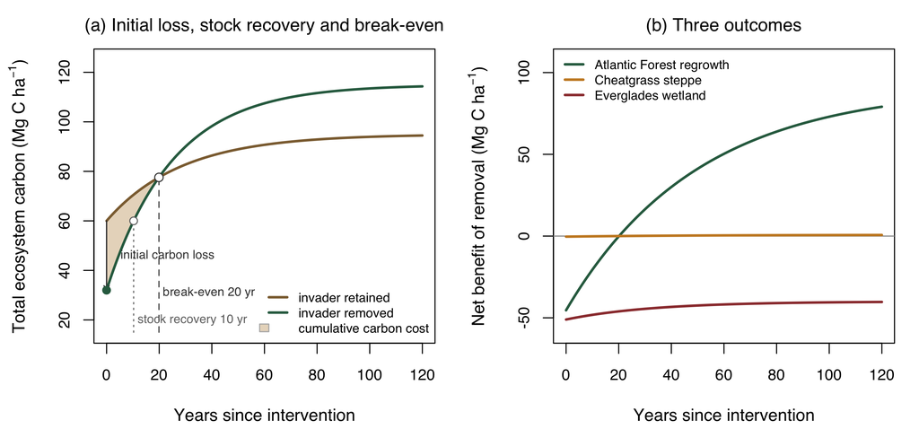

Figure 1: The break-even framework. Left, the general case: removal incurs an immediate initial loss, after which the recovering native trajectory may or may not overtake the counterfactual. Break-even is the crossing, stock recovery the return to the pre-removal stock, and the shaded area the cumulative carbon cost carried until break-even. Right, the three outcomes the framework distinguishes, drawn from the fitted systems.

```r
png(file.path(FIG, "figure-1-concept.png"), width = 2700, height = 1260, res = 300)
op <- par(mfrow = c(1, 2), mar = c(4.2, 4.6, 2.4, 1.2), family = "sans", cex.axis = 0.9)

# panel a: the schematic, drawn from the model itself rather than by hand. The invaded
# state is deliberately given a rising trajectory here, because that is the case in which
# stock recovery and break-even separate and the distinction between them becomes visible.
ps <- list(C_inv = 60, C_nat = 115, K_inv = 95, r_inv = 0.035, r_nat = 0.040, D = 28)
tt <- seq(0, 120, by = 0.5)
yl  <- C_leave(tt, ps$C_inv, ps$K_inv, ps$r_inv)
yr_ <- C_remove(tt, ps$C_inv, ps$D, ps$C_nat, ps$r_nat)
Tp <- breakeven_time(ps); Tb <- recovery_time(ps)
ylim_a <- c(15, 125)
plot(tt, yl, type = "n", ylim = ylim_a, xlab = "Years since intervention",
     ylab = expression("Total ecosystem carbon (Mg C ha"^-1*")"),
     main = "(a) Initial loss, stock recovery and break-even", font.main = 1, cex.main = 1.05)
polygon(c(tt[tt <= Tp], rev(tt[tt <= Tp])),
        c(yl[tt <= Tp], rev(yr_[tt <= Tp])), col = "#e8d9c5", border = NA)
lines(tt, yl,  lwd = 2.4, col = "#8c6d3f")
lines(tt, yr_, lwd = 2.4, col = "#2f6b4f")

# stock recovery and break-even marked at different heights so the labels cannot collide
segments(Tb, ylim_a[1], Tb, ps$C_inv, lty = 3, col = "grey45")
segments(Tp, ylim_a[1], Tp, C_leave(Tp, ps$C_inv, ps$K_inv, ps$r_inv), lty = 2, col = "grey25")
points(Tb, ps$C_inv, pch = 21, bg = "white", col = "grey45", cex = 1.0)
points(Tp, C_leave(Tp, ps$C_inv, ps$K_inv, ps$r_inv), pch = 21, bg = "white",
       col = "grey25", cex = 1.1)
text(Tb, 20, paste0("stock recovery ", sprintf("%.0f", Tb), " yr"),
     pos = 4, cex = 0.72, col = "grey45", offset = 0.2)
text(Tp, 31, paste0("break-even ",  sprintf("%.0f", Tp), " yr"),
     pos = 4, cex = 0.72, col = "grey25", offset = 0.2)

# the initial carbon loss, drawn as a drop at t = 0
arrows(0, ps$C_inv, 0, ps$C_inv - ps$D, length = 0.05, code = 2, col = "grey25", lwd = 1.2)
points(0, ps$C_inv - ps$D, pch = 19, col = "#2f6b4f", cex = 1.0)
text(1.5, 46, "initial carbon loss", pos = 4, cex = 0.72, col = "grey25")
# the shaded band is named in the legend rather than on the panel, because every on-panel
# position for that label collides with either the curves or the break-even marker
legend("bottomright", bty = "n", cex = 0.75, seg.len = 1.6,
       legend = c("invader retained", "invader removed", "cumulative carbon cost"),
       lwd = c(2.4, 2.4, NA), col = c("#8c6d3f", "#2f6b4f", NA),
       fill = c(NA, NA, "#e8d9c5"), border = c(NA, NA, "grey70"))

# panel b: the three outcomes, taken from the fitted systems rather than drawn
cols <- c("#2f6b4f", "#c98a2b", "#9b3b3b")
pick <- res$system_id[order(res$nb100, decreasing = TRUE)]
pick <- pick[c(1, ceiling(length(pick) / 2), length(pick))]
nbmat <- sapply(pick, function(s) sapply(tt, net_benefit, p = pars_point[[s]]))
ylim_b <- range(nbmat, finite = TRUE)
ylim_b <- ylim_b + c(-0.06, 0.22) * diff(ylim_b)   # headroom for the legend
plot(NA, xlim = c(0, 120), ylim = ylim_b, xlab = "Years since intervention",
     ylab = expression("Net benefit of removal (Mg C ha"^-1*")"),
     main = "(b) Three outcomes", font.main = 1, cex.main = 1.05)
abline(h = 0, col = "grey60")
for (i in seq_along(pick)) lines(tt, nbmat[, i], lwd = 2.4, col = cols[i])
legend("topleft", bty = "n", cex = 0.75, lwd = 2.4, seg.len = 1.6, col = cols,
       legend = res$system_short[match(pick, res$system_id)])
par(op); invisible(dev.off())
knitr::include_graphics(file.path(FIG, "figure-1-concept.png"))
```

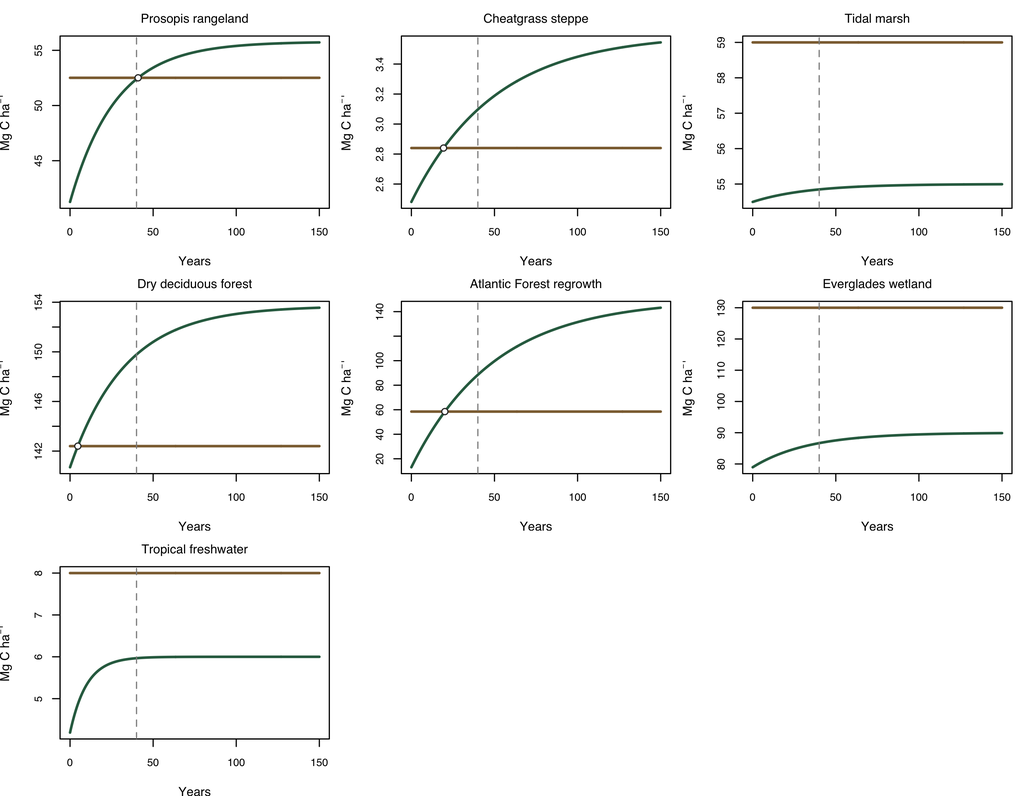

Figure 2: Carbon trajectories under retention and removal for each system. The vertical dashed line marks the end of a 40 year crediting period. Where the removal trajectory remains below the retention trajectory at that point, the project has nothing to claim.

```r
png(file.path(FIG, "figure-2-trajectories.png"), width = 2700, height = 2100, res = 300)
nsys <- nrow(res)
op <- par(mfrow = c(ceiling(nsys / 3), 3), mar = c(3.8, 4.0, 2.4, 0.8),
          family = "sans", cex.axis = 0.85)
tt <- seq(0, 150, by = 0.5)
for (i in seq_len(nsys)) {
  sid <- res$system_id[i]; p <- pars_point[[sid]]
  yl  <- C_leave(tt, p$C_inv, p$K_inv, p$r_inv)
  yr_ <- C_remove(tt, p$C_inv, p$D, p$C_nat, p$r_nat)
  rng <- range(c(yl, yr_), na.rm = TRUE)
  plot(tt, yl, type = "l", lwd = 2.2, col = "#8c6d3f", ylim = rng,
       xlab = "Years", ylab = expression("Mg C ha"^-1),
       main = res$system_short[i], font.main = 1, cex.main = 1.0)
  lines(tt, yr_, lwd = 2.2, col = "#2f6b4f")
  abline(v = CREDIT, lty = 2, col = "grey55")
  Tp <- res$breakeven[i]
  if (is.finite(Tp) && Tp <= 150) points(Tp, C_leave(Tp, p$C_inv, p$K_inv, p$r_inv),
                                          pch = 21, bg = "white", col = "grey20", cex = 1.1)
}
par(op); invisible(dev.off())
knitr::include_graphics(file.path(FIG, "figure-2-trajectories.png"))
```

## 3.2 Sensitivity

```r
# One at a time elasticity: the proportional change in break-even time produced by a ten
# percent increase in each parameter, holding the rest at their point estimates. Where
# break-even is not reached at either the base or the perturbed value the elasticity is
# undefined and reported as such.
#
# One subtlety has to be handled explicitly. Where a source gives no invaded asymptote the
# assembly step sets K_inv equal to C_inv, so the retention trajectory is flat. Perturbing
# C_inv alone would then leave a stale K_inv below the new starting stock and the retention
# curve would bend downward, which is an artefact of the perturbation rather than a property
# of the system. K_inv is therefore moved with C_inv wherever the two were tied.
static_invaded <- sapply(SYS, function(s) isTRUE(all.equal(pars_point[[s]]$K_inv,
                                                           pars_point[[s]]$C_inv)))
names(static_invaded) <- SYS

elasticity <- function(sid, p_name, delta = 0.10) {
  p0 <- pars_point[[sid]]
  t0 <- breakeven_time(p0)
  p1 <- p0
  p1[[p_name]] <- p0[[p_name]] * (1 + delta)
  if (p_name == "C_inv" && static_invaded[[sid]]) p1$K_inv <- p1$C_inv
  p1$D <- initial_loss(p1$AGB_inv, p1$f_rel, p1$dSOC, p1$E_op)
  t1 <- breakeven_time(p1)
  if (!is.finite(t0) || !is.finite(t1) || t0 == 0) return(NA_real_)
  ((t1 - t0) / t0) / delta
}

ELP <- c("C_nat", "r_nat", "AGB_inv", "f_rel", "dSOC", "C_inv")
# short axis labels; the full parameter definitions are in Table 2
ELLAB <- c(C_nat = "Native stock", r_nat = "Recovery rate", AGB_inv = "Invader AGB",
           f_rel = "Released fraction", dSOC = "Soil C loss", C_inv = "Invaded stock")
elas <- outer(SYS, ELP, Vectorize(function(s, p) elasticity(s, p)))
dimnames(elas) <- list(sysmeta$system_short[match(SYS, sysmeta$system_id)], ELP)
```

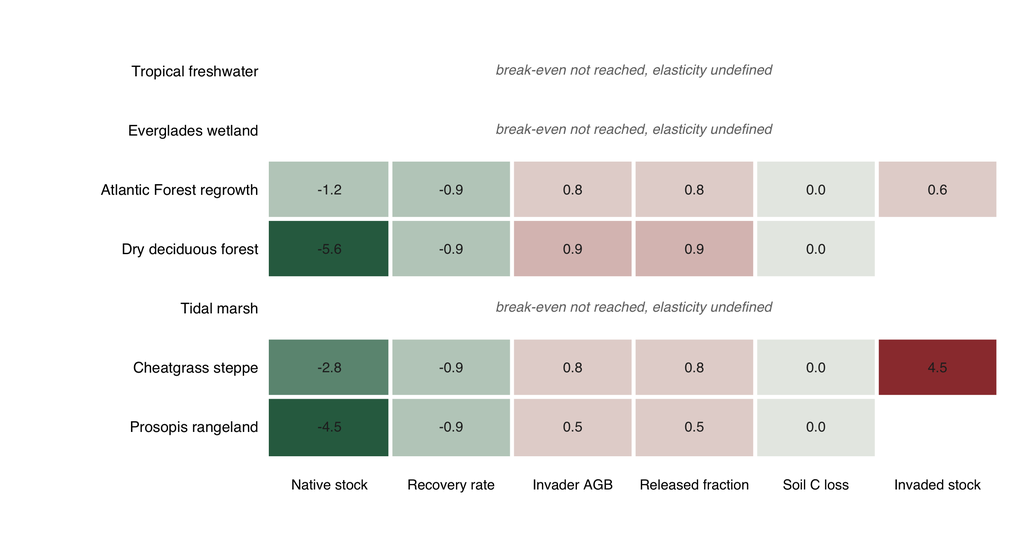

Figure 3: Elasticity of the time to carbon break-even to a ten per cent increase in each parameter, by system. A value of minus one means a ten per cent increase in the parameter shortens the break-even time by ten per cent. Green shortens break-even, red lengthens it. The colour scale is clipped at the ninetieth percentile of absolute elasticity so that a single large value cannot flatten the rest of the panel; the printed values are unclipped. Rows marked undefined are systems in which break-even is not reached, where a proportional change in the break-even time has no meaning.

```r
png(file.path(FIG, "figure-3-sensitivity.png"), width = 2400, height = 1250, res = 300)
op <- par(mar = c(3.0, 10.5, 1.6, 1.0), family = "sans")
z <- t(elas)                                   # parameters on x, systems on y
# the colour scale is clipped at the 90th percentile of absolute elasticity so that a single
# large value cannot flatten the rest of the panel; printed values are unclipped
zcap <- quantile(abs(z), 0.90, na.rm = TRUE)
zc   <- pmin(pmax(z, -zcap), zcap)
brk  <- seq(-zcap, zcap, length.out = 21)
pal  <- colorRampPalette(c("#2f6b4f", "#f2f2ee", "#9b3b3b"))(20)
image(seq_len(nrow(zc)), seq_len(ncol(zc)), zc, col = pal, breaks = brk,
      axes = FALSE, xlab = "", ylab = "")
for (i in seq_len(nrow(z)))
  mtext(unname(ELLAB[rownames(z)[i]]), side = 1, at = i, line = 0.5, cex = 0.66, las = 1)
for (j in seq_len(ncol(z)))
  mtext(colnames(z)[j], side = 2, at = j, line = 0.4, cex = 0.7, las = 1, adj = 1)
abline(h = seq_len(ncol(z)) + 0.5, col = "white", lwd = 3)
abline(v = seq_len(nrow(z)) + 0.5, col = "white", lwd = 3)
for (i in seq_len(nrow(z))) for (j in seq_len(ncol(z)))
  if (is.finite(z[i, j])) text(i, j, sprintf("%.1f", z[i, j]), cex = 0.66, col = "grey15")
# systems where break-even is never reached carry no elasticity at all: say so on the panel
for (j in seq_len(ncol(z))) if (all(!is.finite(z[, j])))
  text(mean(seq_len(nrow(z))), j, "break-even not reached, elasticity undefined",
       cex = 0.66, col = "grey45", font = 3)
par(op); invisible(dev.off())
knitr::include_graphics(file.path(FIG, "figure-3-sensitivity.png"))
```

```r
mean_abs <- sort(colMeans(abs(elas), na.rm = TRUE), decreasing = TRUE)
top_par  <- names(mean_abs)[1]
top_val  <- unname(mean_abs[1])
second   <- names(mean_abs)[2]
second_v <- unname(mean_abs[2])

# effect of the assumed dispersion on unreported parameters: rerun the ordering with a
# coefficient of variation of 0.10 and 0.40 and check that the ranking of systems holds
rank_base <- rank(ifelse(is.finite(res$breakeven_md), res$breakeven_md, Inf))
```

The break-even time is most sensitive to C_nat, with a mean absolute elasticity of 3.52 across systems, and second most sensitive to C_inv at 2.54. An elasticity of one means that a ten per cent change in the parameter moves the break-even time by ten per cent. Elasticities on the recovery rate are negative throughout, as they must be, since faster native reaccumulation shortens the time to break-even. Elasticities on the invader’s own aboveground stock and on the released fraction are positive, since both enlarge the initial loss.

## 3.3 The crediting gap

```r
t4 <- audm
names(t4) <- c("Standard", unname(CRIT))
kable(t4, row.names = FALSE)
write.csv(t4, file.path(TBL, "table-4-standards.csv"), row.names = FALSE)
```

Table 5: Audit of six voluntary carbon standards and one compliance scheme against their own current requirement documents. 0 absent, 1 permitted or implied, 2 explicit. Documents, clauses and retrieval dates are given in the input table.

| Standard | Introduction prohibited | Removal a named eligible activity | Carbon effect of removal creditable | Invader biomass initial loss resolved | Any invasive taxon named | Removal creditable under a non carbon instrument |
| --- | --- | --- | --- | --- | --- | --- |
| Verra | 2 | 2 | 1 | 1 | 1 | 2 |
| Plan Vivo | 1 | 0 | 0 | 0 | 0 | 2 |
| Gold Standard | 2 | 1 | 0 | 0 | 0 | 0 |
| ACR | 2 | 1 | 0 | 0 | 0 | 0 |
| CAR | 1 | 0 | 0 | 0 | 0 | 0 |
| Article 6.4 | 1 | 0 | 0 | 0 | 0 | 0 |
| ACCU | 2 | 2 | 1 | 2 | 0 | 0 |

```r
n_std        <- nrow(audm)
n_prohibit   <- sum(audm$introduce_prohibited >= 1)
n_eligible   <- sum(audm$removal_named_eligible >= 1)
n_credit     <- sum(audm$removal_creditable_carbon >= 2)
n_lossresolved       <- sum(audm$biomass_loss_resolved >= 2)
n_noncarbon  <- sum(audm$creditable_non_carbon >= 2)
```

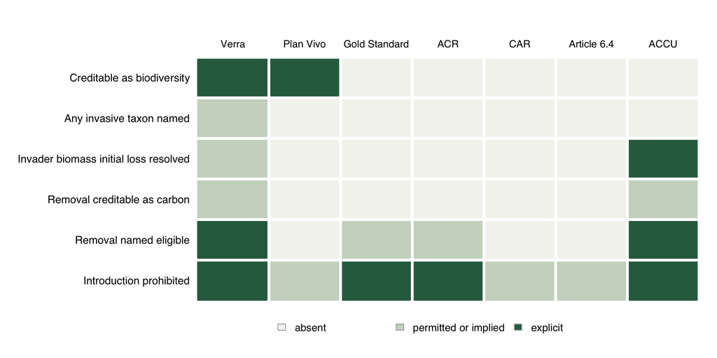

Figure 4: The crediting gap. Every regime restricts the introduction of invasive species; none credits the carbon consequence of removing them. Only the Australian compliance scheme resolves the biomass initial loss, and it does so by assuming the removal would have happened anyway.

```r
# short labels for the figure only; the full criterion wording is in Table 4
CRITSHORT <- c(introduce_prohibited      = "Introduction prohibited",
               removal_named_eligible    = "Removal named eligible",
               removal_creditable_carbon = "Removal creditable as carbon",
               biomass_loss_resolved     = "Invader biomass initial loss resolved",
               species_named             = "Any invasive taxon named",
               creditable_non_carbon     = "Creditable as biodiversity")

png(file.path(FIG, "figure-4-audit.png"), width = 2400, height = 1200, res = 300)
op <- par(mar = c(3.2, 11.0, 3.2, 1.0), family = "sans")
m <- as.matrix(audm[, names(CRIT)])
rownames(m) <- audm$standard_short
image(seq_len(nrow(m)), seq_len(ncol(m)), m, col = c("#f4f4f0", "#cbd8c8", "#2f6b4f"),
      breaks = c(-0.5, 0.5, 1.5, 2.5), axes = FALSE, xlab = "", ylab = "")
# labels are drawn one at a time, because axis() silently drops labels that would overlap
# and that dropped "Gold Standard" from an earlier version of this figure
for (i in seq_len(nrow(m)))
  mtext(rownames(m)[i], side = 3, at = i, line = 0.35, cex = 0.68, las = 1)
for (j in seq_len(ncol(m)))
  mtext(unname(CRITSHORT)[j], side = 2, at = j, line = 0.4, cex = 0.72, las = 1, adj = 1)
abline(h = seq_len(ncol(m)) + 0.5, col = "white", lwd = 3)
abline(v = seq_len(nrow(m)) + 0.5, col = "white", lwd = 3)
legend("bottom", horiz = TRUE, bty = "n", cex = 0.7, inset = -0.16, xpd = NA,
       fill = c("#f4f4f0", "#cbd8c8", "#2f6b4f"), border = "grey70",
       legend = c("absent", "permitted or implied", "explicit"))
par(op); invisible(dev.off())
knitr::include_graphics(file.path(FIG, "figure-4-audit.png"))
```

The asymmetry between the columns is the finding. The obligation runs one way throughout. A proponent may be required to demonstrate that invasive populations have not increased, and may in some regimes be encouraged to eradicate, while having no mechanism by which the carbon result of doing so can be quantified or paid for. 2 of the regimes credit removal under a non-carbon instrument, scoring invasive abundance as a biodiversity outcome, which is the only place in the voluntary market where the activity is currently rewarded on its own terms.

## 3.4 Where the break-even answer and the crediting answer meet

```r
t5 <- data.frame(
  System = res$system_short,
  `Claimable at 40 yr` = ifelse(res$claimable, "yes", "no"),
  # a initial loss share far above 100 per cent means the benefit is near zero rather than that the
  # initial loss is unusually large, so the ratio is capped for display and read with the benefit column
  `Initial loss as share of benefit` = ifelse(!is.finite(res$loss_share), "-",
                               ifelse(res$loss_share > 10, "over 1000%", pc(res$loss_share))),
  `Passes de minimis` = ifelse(is.na(res$deminimis), "-", ifelse(res$deminimis, "yes", "no")),
  Verdict = res$verdict,
  `Available route` = res$route,
  check.names = FALSE, stringsAsFactors = FALSE)
kable(t5, row.names = FALSE)
write.csv(t5, file.path(TBL, "table-5-verdict.csv"), row.names = FALSE)
```

Table 6: Joint verdict. For each system, whether removal generates a claimable carbon benefit within a 40 year crediting period, whether the initial carbon loss is small enough to pass the 5 percent de minimis test that would otherwise require it to be accounted explicitly, and the crediting route that could accommodate it.

| System | Claimable at 40 yr | Initial loss as share of benefit | Passes de minimis | Verdict | Available route |
| --- | --- | --- | --- | --- | --- |
| Prosopis rangeland | no | - | no | no claimable benefit at 40 yr | VM0042 grassland, or VM0044 biochar feedstock |
| Cheatgrass steppe | no | - | no | no claimable benefit at 40 yr | VM0045 matched baseline, forest only |
| Tidal marsh | no | - | no | no claimable benefit at 40 yr | VM0033, removal a named eligible activity |
| Dry deciduous forest | yes | 30% | no | claimable, initial loss must be accounted | VM0045 design, no approved jurisdiction |
| Atlantic Forest regrowth | yes | 178% | no | claimable, initial loss must be accounted | VM0047 site preparation carve-out |
| Everglades wetland | no | - | no | no claimable benefit at 40 yr | VM0033, removal a named eligible activity |
| Tropical freshwater | no | - | no | no claimable benefit at 40 yr | VM0044 biochar, aquatic feedstock named |

# 4. Discussion

```r
# values quoted in the discussion, computed rather than typed
n_never    <- sum(res$p_never > 0.5)
n_fast     <- sum(is.finite(res$breakeven_md) & res$breakeven_md <= 20)
n_claim    <- sum(res$claimable)
n_dem      <- sum(res$deminimis, na.rm = TRUE)
worst      <- res$system_short[which.min(res$nb40_md)]
best       <- res$system_short[which.max(res$nb40_md)]
span_lo    <- min(res$breakeven_md, na.rm = TRUE)
span_hi    <- max(res$breakeven_md, na.rm = TRUE)
r_nat_elas <- mean(abs(elas[, "r_nat"]), na.rm = TRUE)
agb_elas   <- mean(abs(elas[, "AGB_inv"]), na.rm = TRUE)
```

## 4.2 The standards cannot express the answer, in either direction

The audit returns a uniform result across regimes that otherwise share very little. All 7 prohibit or discourage the introduction of invasive species. 4 name removal as an eligible or permitted activity somewhere in their documents. 0 provide a route by which the carbon consequence of removal can itself be credited. The obligation is negative throughout: do not introduce, do not let populations rise. Nowhere in the voluntary market is there an instrument that asks whether removing an established invader would be a carbon gain, because nowhere is there an instrument that could act on the answer.

Two features of the current rules make this more than an omission. The first is that clearing pre-existing woody biomass is tested against a rule written to catch baseline gaming, and a genuine removal project fails that test on its face. Verra’s own consultation record shows proponents asking what threshold of clearing is permissible and being told that no quantitative threshold exists, with the answer falling back on a de minimis allowance that requires the omitted decrease to stay below five per cent of the project’s total benefit. Of the systems examined here, 2 generate a positive benefit inside a forty year crediting period at all, and 0 of those carry a initial loss small enough to pass that test. For the remainder, the initial loss must be accounted explicitly, and no approved methodology outside the matched baseline design provides a way to do so.

The second is that the eligibility machinery has been built while the quantification machinery has not. Verra’s tidal wetland methodology has listed the removal of invasive species as an eligible activity since 2015, and the programme standard has carried an eligibility route for land whose dominant cover is an invasive species threatening ecosystem health. A proponent can therefore establish that a site qualifies and then discover there is no way to quantify what the project does to it. The recent tightening of that route, from a blanket exemption to an evidentiary test requiring a defined dominance threshold, sharpens the mismatch rather than resolving it.

## 4.3 One accounting design already dissolves the problem

The dynamic matched baseline is the exception, and it appears not to have been recognised as one. Where the counterfactual is constructed from matched control plots rather than modelled forward from the project site, the invader stands in both the project and the control. Its removal is then not an emission against the baseline, because the baseline contains it too, and the credit attaches to the differential growth of the regeneration that removal releases. The problem that defeats every other methodology is dissolved by the structure of the comparison rather than by an exemption.

The constraint on that design is jurisdictional and structural, not conceptual. It requires a national forest inventory dense enough to supply matched controls, which at present means the conterminous United States, and it requires forest that remains forest, which excludes every marsh, rangeland and open ecosystem in this study. Extending matched baselines to non-forest biomes is a tractable research programme with an existing template, and it is the single change that would do most to make invasive removal creditable where removal actually pays.

Two routes already monetise the activity, and it is worth being precise about what they pay for. Converting cleared invasive biomass to biochar moves the carbon from the land pool to a durable pool, so the land carbon loss is compensated rather than avoided, which is why the biochar route changes the arithmetic and not merely the finance. Crediting invasive control as a biodiversity outcome, as Verra’s nature framework and Plan Vivo’s nature standard both now do, pays for the ecological result directly and never touches the carbon question. Neither rewards the land carbon effect of removal, and on the evidence assembled here, for most systems neither should.

## 4.4 The symmetry: retention cannot be credited either

The systems in which break-even is never reached are, read the other way, the systems in which the carbon-rational action is to leave the invader standing. That is not a rhetorical inversion. It is the same arithmetic stated from the other end, and it applies to 3 of the 7 systems examined here. Nor is it a hypothetical position: working in Ethiopian rangelands, Birhane and colleagues found woody carbon roughly 40 per cent higher under dense *Prosopis* encroachment than under sparse, and proposed carbon trading on densely invaded land rather than eradication (Birhane, Treydte, Eshete, Solomon, & Hailemariam, 2017). On carbon grounds alone that proposal follows from the evidence.

Retention cannot be credited either, and the reason is worth stating precisely because it is structural rather than ideological. Retention is inaction, inaction is the baseline, and an activity cannot be additional to itself. The only route by which retention could generate credits would be to establish that clearance was the counterfactual, which at the scale of the invaded estate is demonstrably false: the registry search underlying this paper found no project anywhere for which invasive plant control is the primary crediting activity. Crediting retention would therefore require either abandoning additionality or asserting a threat of clearance that does not exist.

The result is a symmetry that has not, as far as we are aware, been stated. Removal cannot be credited because clearing a woody invader is an emission against a carbon-rich baseline and is indistinguishable, on the face of the applicable test, from deliberately lowering that baseline. Retention cannot be credited because it is the baseline. Whichever action the carbon arithmetic favours, the accounting returns nothing. The invaded estate is uncreditable in both directions, and it is uncreditable regardless of the ecological facts, which is a different and more serious problem than a missing methodology.

The prohibition that produces this outcome is not unreasonable. A categorical rule, never introduce invasive species and never allow their populations to rise, is cheap to verify and hard to game, and the recent record of outcome-based crediting in the land sector makes the preference for such rules easy to understand. The cost of a categorical rule is that it produces false negatives wherever its premise does not hold, and this paper identifies the class of cases where it does not: sites at which the invader is the dominant carbon pool, the native community is not recoverable at reasonable cost, and the standards nevertheless require that invasive populations not increase.

That places the argument squarely inside an older and unresolved debate. Hobbs and colleagues argued that systems which have crossed a threshold should be managed for function rather than restored to historical composition (Hobbs, Higgs, & Harris, 2009); Murcia and colleagues replied that the concept is too loosely specified to be operational and in practice licenses the abandonment of restoration (Murcia et al., 2014). The parallel argument over whether provenance should determine management value ran through the same period (Davis et al., 2011; Schlaepfer, Sax, & Olden, 2011). Our contribution to that debate is narrow but quantitative: for a defined subset of invaded systems the carbon ledger favours retention, and no crediting instrument can express that preference in either direction.

We do not conclude that retention should therefore be credited. The decisive objection is leakage. A payment for retaining an invader is a payment for maintaining a propagule source that continues to invade neighbouring land, and a stock-based accounting captures the retained carbon while externalising the spread. Any serious proposal to credit retention would need to internalise that externality, and none of the accounting designs reviewed here can do so. A second and more practical obstacle is that retention is often not a policy choice at all: *Prosopis* regains cover within months of cutting, and roughly a quarter of treated *Phragmites* sites are recolonised after apparent eradication, so the realistic question in much of the invaded world is not whether to retain but whether to account for what will persist regardless.

## 4.6 Limitations

The most consequential limitation is the counterfactual, and it belongs to the field rather than to this analysis. Section 2.3 shows that on the one site where all the relevant classes were measured, the sign of the estimated carbon effect of invasion changes with the comparison chosen, across a range of 23.6 Mg C per hectare. Every break-even time reported here is conditional on the retention counterfactual and would differ under the others. More awkwardly, the parameters entering the model come from studies that overwhelmingly compare invaded plots against an uninvaded reference of unreported land-use history, so the inputs may already embed a different and unstated counterfactual from the one the model applies. Only the Kenyan rangeland carries a degraded-but-uninvaded class that would allow the two to be separated. We regard this as the central methodological problem of the invasion-carbon literature and treat it at length elsewhere.

The model is otherwise deliberately simple. Both trajectories are monomolecular approaches to an asymptote, which represents stock recovery adequately but cannot represent a system that overshoots, collapses, or is reinvaded. Secondary invasion after clearing is common and is not modelled; where it occurs, the real break-even times will be longer than those reported here and in some systems break-even will be lost entirely.

The accounting boundary is carbon stock only. Three consequences follow. Methane and nitrous oxide are excluded, which matters most in the wetland and aquatic systems, where the flux literature is unresolved and in the case of floating aquatics the stock framing may be the wrong one altogether (Z. Gu et al., 2025; Martin & Moseman-Valtierra, 2017). Fire regime feedbacks are excluded, which understates the case for removing invasive annual grasses, since the invasion-fire cycle removes carbon that a stock comparison of unburned states does not see. And the durable-product fate of cleared biomass is treated as a parameter rather than a scenario.

Finally, the break-even framework inherits a known fragility. In the bioenergy literature, methodological choices alone swing stock recovery times from under a year to twenty-seven and break-even from two years to more than a century (Jonker et al., 2014). Fixing the accounting boundary and the counterfactual before computing anything, as done here, contains that problem without eliminating it, and cross-study comparison of break-even times should be treated with the same caution the bioenergy literature learned to apply.

# 5. Conclusion

The question of whether invasive plant removal is a carbon gain has an answer, and the answer is that it depends on the invader in a way that is predictable from its functional type and computable from data that already exists for some systems and conspicuously does not for others. Where the invader holds little carbon and suppresses a system capable of holding much, removal repays quickly. Where the invader is the dominant carbon pool, removal does not repay on any horizon a crediting period can reach, and in the systems where the invader outperforms the community it displaced, it does not repay at all.

The carbon standards cannot act on that answer in either direction, and the failure is symmetrical. Removal cannot be credited, because clearing a woody invader is an emission against a carbon-rich baseline and is indistinguishable, on the face of the applicable test, from deliberately lowering that baseline. Retention cannot be credited, because retention is the baseline and nothing can be additional to itself. Whichever action the arithmetic favours, the accounting returns nothing. The standards have built the eligibility machinery for invaded land while leaving the quantification machinery unbuilt, and the one accounting design that dissolves the underlying problem is confined to forest in a single country. The result is an activity that is simultaneously required as a safeguard, named as eligible, and impossible to credit, sitting on land whose carbon-optimal alternative is equally impossible to credit.

That the answer also depends on the counterfactual compounds the problem rather than relieving it. On the one site in this study where the intact, degraded and restored classes were all measured, invasion is a carbon loss against one comparison and a gain against the other two, across a range wider than the invaded stand’s entire aboveground stock. A crediting system must fix a counterfactual in advance and apply it categorically. It therefore fixes the sign of the answer before the ecology is consulted.

Two things follow. The narrow one is technical: extending dynamic matched baselines beyond forest would make removal creditable in the systems where the break-even calculation says it should be. The broader one is that carbon is the wrong lens for most of this work. The systems where removal costs the most carbon are often those where it delivers the most biodiversity, and a mechanism that ranks restoration by carbon will defund exactly the removals with the strongest ecological case. The emerging biodiversity credit instruments, which already score invasive abundance directly, are the better fit. The break-even calculation should decide which instrument applies, and for a large share of the invaded world it says the answer is not carbon.

# Data availability

# Conflict of interest

The author declares no conflict of interest, and no financial relationship with any carbon standard, registry, project developer or verification body assessed in the standards audit.

# Funding

No funding was received for this work.

# Author contributions

Sole authorship. Following the CRediT taxonomy, the author is responsible for conceptualization, methodology, software, formal analysis, investigation, data curation, visualization, and writing of the original draft and its revision.

# Use of generative artificial intelligence

# Acknowledgements

Standards documents were retrieved from the public repositories of Verra, Plan Vivo, the Gold Standard, the American Carbon Registry, the Climate Action Reserve, the UNFCCC and the Australian Federal Register of Legislation between 29 and 30 July 2026. Version numbers and retrieval dates are recorded in the input table, because several of the documents assessed were revised during the period in which comparable analyses have been published.

# References

Ahmad, R., Lone, S. A., Phartyal, S. S., Mungi, N. A., Singh, K., & Khuroo, A. A. (2026). [Turning the tide on invasives: A global meta-analysis of native revegetation strategies for effective restoration](https://doi.org/10.1111/1365-2664.70396). *Journal of Applied Ecology*, *63*(5), e70396.

Birhane, E., Treydte, A. C., Eshete, A., Solomon, N., & Hailemariam, M. (2017). [Can rangelands gain from bush encroachment? Carbon stocks of communal grazing lands invaded by *Prosopis juliflora*](https://doi.org/10.1016/j.jaridenv.2017.01.003). *Journal of Arid Environments*, *141*, 60–67.

Campbell, E., & Campbell, A. (2026). [The case for and against *Phragmites australis*: An ecosystem service cost-benefit analysis for Chesapeake Bay marshes](https://doi.org/10.1007/s11273-026-10120-4). *Wetlands Ecology and Management*, *34*(2), 19.

Convention on Biological Diversity. (2022). Decision 15/4. Kunming-Montreal global biodiversity framework. Document CBD/COP/DEC/15/4, Montreal, 19 December 2022. Retrieved from https://www.cbd.int/doc/decisions/cop-15/cop-15-dec-04-en.pdf

Davis, M. A., Chew, M. K., Hobbs, R. J., Lugo, A. E., Ewel, J. J., Vermeij, G. J., Brown, J. H., et al. (2011). [Don’t judge species on their origins](https://doi.org/10.1038/474153a). *Nature*, *474*(7350), 153–154.

Diagne, C., Leroy, B., Vaissière, A.-C., Gozlan, R. E., Roiz, D., Jarić, I., Salles, J.-M., et al. (2021). [High and rising economic costs of biological invasions worldwide](https://doi.org/10.1038/s41586-021-03405-6). *Nature*, *592*(7855), 571–576.

Fargione, J., Hill, J., Tilman, D., Polasky, S., & Hawthorne, P. (2008). [Land clearing and the biofuel carbon debt](https://doi.org/10.1126/science.1152747). *Science*, *319*(5867), 1235–1238.

Ferraro, P. J., & Pattanayak, S. K. (2006). [Money for nothing? A call for empirical evaluation of biodiversity conservation investments](https://doi.org/10.1371/journal.pbio.0040105). *PLoS Biology*, *4*(4), e105.

Gu, J., Ardenne, L. B. van, & Chmura, G. L. (2020). [Invasive *Phragmites* increases blue carbon stock and soil volume in a St. Lawrence estuary marsh](https://doi.org/10.1029/2019JG005473). *Journal of Geophysical Research: Biogeosciences*, *125*(8), e2019JG005473.

Gu, Z., Zhou, L., Fu, Y., Long, J., Zhang, Z., Miao, Y., Guo, L., et al. (2025). [Invasive C4 plants cause greater soil greenhouse gas emissions than C3 plants](https://doi.org/10.1038/s43247-025-02844-7). *Communications Earth and Environment*, *6*(1), 936.

He, Y., Li, J., Siemann, E., Li, B., Xu, Y., & Wang, Y. (2025). [Plant invasion increases soil microbial biomass carbon: Meta-analysis and empirical tests](https://doi.org/10.1111/gcb.70109). *Global Change Biology*, *31*(3), e70109.

Hobbs, R. J., Higgs, E., & Harris, J. A. (2009). [Novel ecosystems: Implications for conservation and restoration](https://doi.org/10.1016/j.tree.2009.05.012). *Trends in Ecology and Evolution*, *24*(11), 599–605.

Honzák, M., Roberts, G., Cosentino, B. J., Sexton, J. O., McKenzie-McHarg, H., Wilson, J. W., Feng, M., et al. (2024). [Toward the quantification of the climate co-benefits of invasive mammal eradication on islands: A scalable framework for restoration monitoring](https://doi.org/10.1088/1748-9326/ad77b7). *Environmental Research Letters*, *19*(11), 114018.

IPBES. (2023). *[Thematic assessment report on invasive alien species and their control of the intergovernmental science-policy platform on biodiversity and ecosystem services](https://doi.org/10.5281/zenodo.7430682)*. (H. E. Roy, A. Pauchard, P. Stoett, & T. Renard Truong, Eds.). Bonn, Germany: IPBES secretariat.

Jonker, J. G. G., Junginger, M., & Faaij, A. (2014). [Carbon payback period and carbon offset parity point of wood pellet production in the South-eastern United States](https://doi.org/10.1111/gcbb.12056). *GCB Bioenergy*, *6*(4), 371–389.

Lane, R. R., Mack, S. K., Day, J. W., DeLaune, R. D., Madison, M. J., & Precht, P. R. (2016). [Fate of soil organic carbon during wetland loss](https://doi.org/10.1007/s13157-016-0834-8). *Wetlands*, *36*(6), 1167–1181.

Liao, C., Peng, R., Luo, Y., Zhou, X., Wu, X., Fang, C., Chen, J., et al. (2008). [Altered ecosystem carbon and nitrogen cycles by plant invasion: A meta-analysis](https://doi.org/10.1111/j.1469-8137.2007.02290.x). *New Phytologist*, *177*(3), 706–714.

Martin, R. M., & Moseman-Valtierra, S. (2017). [Effects of transient *Phragmites australis* removal on brackish marsh greenhouse gas fluxes](https://doi.org/10.1016/j.atmosenv.2017.03.025). *Atmospheric Environment*, *158*, 51–59.

Matos, F. A. R., Edwards, D. P., Magnago, L. F. S., Heringer, G., Neri, A. V., Buttschardt, T., Zenni, R. D., et al. (2023). [Invasive alien acacias rapidly stock carbon, but threaten biodiversity recovery in young second-growth forests](https://doi.org/10.1098/rstb.2021.0072). *Philosophical Transactions of the Royal Society B: Biological Sciences*, *378*(1867), 20210072.

Mitchell, S. R., Harmon, M. E., & O’Connell, K. E. B. (2012). [Carbon debt and carbon sequestration parity in forest bioenergy production](https://doi.org/10.1111/j.1757-1707.2012.01173.x). *GCB Bioenergy*, *4*(6), 818–827.

Murcia, C., Aronson, J., Kattan, G. H., Moreno-Mateos, D., Dixon, K., & Simberloff, D. (2014). [A critique of the ’novel ecosystem’ concept](https://doi.org/10.1016/j.tree.2014.07.006). *Trends in Ecology and Evolution*, *29*(10), 548–553.

Negesse, Z., Pan, K., Guadie, A., Justine, M. F., Azene, B., Pandey, B., Wu, X., et al. (2025). [Plant invasions alter soil biota and microbial activities: A global meta-analysis](https://doi.org/10.1007/s11104-025-07227-7). *Plant and Soil*, *513*(1), 1031–1050.

Peltzer, D. A., Allen, R. B., Lovett, G. M., Whitehead, D., & Wardle, D. A. (2010). [Effects of biological invasions on forest carbon sequestration](https://doi.org/10.1111/j.1365-2486.2009.02038.x). *Global Change Biology*, *16*(2), 732–746.

Raheem, A., Yohanna, P., Li, G., Noh, N. J., Iqbal, B., Tang, J., Du, D., et al. (2024). [Unraveling the ecological threads: How invasive alien plants influence soil carbon dynamics](https://doi.org/10.1016/j.jenvman.2024.120556). *Journal of Environmental Management*, *356*, 120556.

Schlaepfer, M. A., Sax, D. F., & Olden, J. D. (2011). [The potential conservation value of non-native species](https://doi.org/10.1111/j.1523-1739.2010.01646.x). *Conservation Biology*, *25*(3), 428–437.

Searchinger, T., Heimlich, R., Houghton, R. A., Dong, F., Elobeid, A., Fabiosa, J., Tokgoz, S., et al. (2008). [Use of U.S. Croplands for biofuels increases greenhouse gases through emissions from land-use change](https://doi.org/10.1126/science.1151861). *Science*, *319*(5867), 1238–1240.

Vilà, M., Espinar, J. L., Hejda, M., Hulme, P. E., Jarošík, V., Maron, J. L., Pergl, J., et al. (2011). [Ecological impacts of invasive alien plants: A meta-analysis of their effects on species, communities and ecosystems](https://doi.org/10.1111/j.1461-0248.2011.01628.x). *Ecology Letters*, *14*(7), 702–708.

Wilgen, B. W. van, Forsyth, G. G., Le Maitre, D. C., Wannenburgh, A., Kotzé, J. D. F., Berg, E. van den, & Henderson, L. (2012). [An assessment of the effectiveness of a large, national-scale invasive alien plant control strategy in South Africa](https://doi.org/10.1016/j.biocon.2011.12.035). *Biological Conservation*, *148*(1), 28–38.

Wilgen, B. W. van, & Wannenburgh, A. (2016). [Co-facilitating invasive species control, water conservation and poverty relief: Achievements and challenges in South Africa’s Working for Water programme](https://doi.org/10.1016/j.cosust.2015.08.012). *Current Opinion in Environmental Sustainability*, *19*, 7–17.